# Assignment 5 - Uber Case

Chiebuka Onwuzurike

# Install the packages if you don’t have them installed yet. Install them only once, and not when you run your knitting.

### 1. Read the HBS Case. What is the difference between Uber POOL and Express POOL? No more than two sentences.

Uber Pool is a product that offers a discounted fares for riders willing to carpool with other passengers, while still providing door-to-door pickup and drop-off service. Uber Express Pool is just like Uber Pool however, riders need to make a short walk to pickup and drop-off locations for even large discounted fares.

### 2. How did Uber use surveys in designing Uber Express Pool?No more than two sentences.

Surveys helped Uber realized a floor and ceiling for pricing and tha most people simply will not wait 15 minutes for a ride ven if prices are far cheaper.

### 3. Suppose Uber was considering a new algorithm to recommend ride destinations in the app. Which type of research strategy should they use (A/B Test, Switchback, Synthetic Control)? No more than two sentences.

I’d suggest a switchback strategy because since the treatment will be applied in our app we can control the switching back and forth. Additionally we will be able to reduce the noise from different days or times of day.

### 4. Suppose Uber was considering a radio advertising campaign. Which type of research strategy should they use (A/B Test, Switchback, Synthetic Control)? No more than two sentences.

Synthetic control because there may not be significant difference on when an ad is shown (no need for switch back), however we may still need to cluster to remove noise. Additionally when showing an add we need to use another 3rd party to advertise such as a radio station and won’t have full control of the implementation.

### 5. Create two new columns in the dataset that represent the total number of trips for both pool products and the profit from these products. (10 points)

```r
data[, total_trips := trips_pool + trips_express_pool]
data[, profit := revenue - total_driver_payout_sr]
```

### 6. Plot the average number of trips as a function of the time of the day. Describe a reason why this pattern exists (no more than 2 sentences). (20 points)

Most days the average number of trips are the same however, 7:00 and 15:00 are busier hours with increased demand in general.

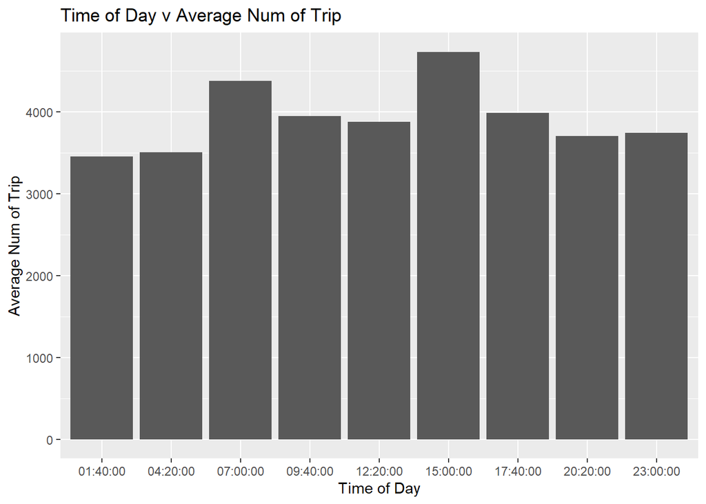

```r
data_avg_trip_time <- data[, list( avg_trips = mean(total_trips)), list(time_of_day)]
ggplot(data_avg_trip_time, aes(x = time_of_day, y = avg_trips)) + geom_bar(stat = 'identity')+
labs (x= "Time of Day", y= "Average Num of Trip", title= "Time of Day v Average Num of Trip")
```

# B: Regression analysis of outcomes.

### 7. Conduct a regression analysis of the experiment (considering the outcomes: revenue, total_driver_payout_sr, rider_cancellations, total_trips). Make sure to think carefully about the correct regression specification. The regression output should be easy to read, so use ‘etable’ or ‘modelsummary’. What do you learn in words from this regression analysis (no more than 5 sentences but it can be less)?

```r
regs <- feols( c(profit, revenue, total_driver_payout_sr, rider_cancellations, total_trips)~ treat | time_of_day + date, data, se= "white")
etable(regs)
```

```
##                            model 1        model 2                model 3
## Dependent Var.:             profit        revenue total_driver_payout_sr
##
## treatTRUE       1,829.8*** (496.8) -170.6 (930.5)      -2,000.4* (775.0)
## Fixed-Effects:  ------------------ -------------- ----------------------
## time_of_day                    Yes            Yes                    Yes
## date                           Yes            Yes                    Yes
## _______________ __________________ ______________ ______________________
## S.E. type       Heteroskedas.-rob. Heterosk.-rob. Heteroskedastici.-rob.
## Observations                   126            126                    126
## R2                         0.42068        0.57973                0.50234
## Within R2                  0.11961        0.00035                0.06308
##                             model 4        model 5
## Dependent Var.: rider_cancellations    total_trips
##
## treatTRUE          26.63*** (7.058) -80.86 (81.19)
## Fixed-Effects:  ------------------- --------------
## time_of_day                     Yes            Yes
## date                            Yes            Yes
## _______________ ___________________ ______________
## S.E. type       Heteroskedast.-rob. Heterosk.-rob.
## Observations                    126            126
## R2                          0.55432        0.50728
## Within R2                   0.12685        0.00997
```

### 8. One of your data scientists suggests that the optimal wait time may differ by whether it’s a commuting period. Test whether the effects of a 5 minute wait period on total trips and cancelations differ by whether it’s a commuting period (the column ‘commute’). Which policy works better during commute times? (10 points)

```r
regs_commute_true <- feols( c(profit,total_trips,rider_cancellations)~ commute | time_of_day + date, data[treat==TRUE,], se= "white")
etable(regs_commute_true)
```

```
##                            model 1            model 2             model 3
## Dependent Var.:             profit        total_trips rider_cancellations
##
## commuteTRUE     4,275.4* (1,947.6) 1,288.2*** (221.5)    146.3*** (13.56)
## Fixed-Effects:  ------------------ ------------------ -------------------
## time_of_day                    Yes                Yes                 Yes
## date                           Yes                Yes                 Yes
## _______________ __________________ __________________ ___________________
## S.E. type       Heteroskedas.-rob. Heteroskedas.-rob. Heteroskedast.-rob.
## Observations                    63                 63                  63
## R2                         0.51123            0.74807             0.90656
## Within R2                  0.10455            0.44455             0.73792
```

```r
regs_commute_false <- feols( c(profit,total_trips,rider_cancellations)~ commute | time_of_day + date, data[treat==FALSE,], se= "white")
etable(regs_commute_false)
```

```
##                            model 1            model 2             model 3
## Dependent Var.:             profit        total_trips rider_cancellations
##
## commuteTRUE     3,107.6* (1,301.9) 1,193.1*** (192.5)    99.38*** (21.04)
## Fixed-Effects:  ------------------ ------------------ -------------------
## time_of_day                    Yes                Yes                 Yes
## date                           Yes                Yes                 Yes
## _______________ __________________ __________________ ___________________
## S.E. type       Heteroskedas.-rob. Heteroskedas.-rob. Heteroskedast.-rob.
## Observations                    63                 63                  63
## R2                         0.60780            0.78238             0.67482
## Within R2                  0.09632            0.39009             0.32552
```

# How much time did this assignment take you? How hard was it? (easy, moderate, hard, too hard)